# Reproducible Research: Peer Assessment 1

## Loading and preprocessing the data

**Load the Data and remove the missing values in the dataset**

- Reading the data from the csv file and parsing the date using the lubridate package
  - origActivity has all the rows including the ones that have NA’s
  - activity has all rows that have no NA’s
  - activityNA has only rows that have NA’s

```r
unzip("./activity.zip", exdir = "./")
origActivity = read.csv("./activity.csv")
origActivity$date = ymd(origActivity$date, tz=Sys.timezone(location = TRUE))
activity = subset(origActivity, !is.na(steps))
activityNA = subset(origActivity, is.na(steps))
```

**Take a look at the Structure of the Data**

```r
str(origActivity)
```

```
## 'data.frame':    17568 obs. of  3 variables:
##  $ steps   : int  NA NA NA NA NA NA NA NA NA NA ...
##  $ date    : POSIXct, format: "2012-10-01" "2012-10-01" ...
##  $ interval: int  0 5 10 15 20 25 30 35 40 45 ...
```

```r
str(activity)
```

```
## 'data.frame':    15264 obs. of  3 variables:
##  $ steps   : int  0 0 0 0 0 0 0 0 0 0 ...
##  $ date    : POSIXct, format: "2012-10-02" "2012-10-02" ...
##  $ interval: int  0 5 10 15 20 25 30 35 40 45 ...
```

```r
str(activityNA)
```

```
## 'data.frame':    2304 obs. of  3 variables:
##  $ steps   : int  NA NA NA NA NA NA NA NA NA NA ...
##  $ date    : POSIXct, format: "2012-10-01" "2012-10-01" ...
##  $ interval: int  0 5 10 15 20 25 30 35 40 45 ...
```

**Summary of the Data**

```r
summary(origActivity)
```

```
##      steps             date                        interval
##  Min.   :  0.00   Min.   :2012-10-01 00:00:00   Min.   :   0.0
##  1st Qu.:  0.00   1st Qu.:2012-10-16 00:00:00   1st Qu.: 588.8
##  Median :  0.00   Median :2012-10-31 00:00:00   Median :1177.5
##  Mean   : 37.38   Mean   :2012-10-31 00:25:34   Mean   :1177.5
##  3rd Qu.: 12.00   3rd Qu.:2012-11-15 00:00:00   3rd Qu.:1766.2
##  Max.   :806.00   Max.   :2012-11-30 00:00:00   Max.   :2355.0
##  NA's   :2304
```

```r
summary(activity)
```

```
##      steps             date                        interval
##  Min.   :  0.00   Min.   :2012-10-02 00:00:00   Min.   :   0.0
##  1st Qu.:  0.00   1st Qu.:2012-10-16 00:00:00   1st Qu.: 588.8
##  Median :  0.00   Median :2012-10-29 00:00:00   Median :1177.5
##  Mean   : 37.38   Mean   :2012-10-30 17:37:21   Mean   :1177.5
##  3rd Qu.: 12.00   3rd Qu.:2012-11-16 00:00:00   3rd Qu.:1766.2
##  Max.   :806.00   Max.   :2012-11-29 00:00:00   Max.   :2355.0
```

```r
summary(activityNA)
```

```
##      steps           date                        interval
##  Min.   : NA    Min.   :2012-10-01 00:00:00   Min.   :   0.0
##  1st Qu.: NA    1st Qu.:2012-10-26 00:00:00   1st Qu.: 588.8
##  Median : NA    Median :2012-11-06 11:30:00   Median :1177.5
##  Mean   :NaN    Mean   :2012-11-01 21:30:00   Mean   :1177.5
##  3rd Qu.: NA    3rd Qu.:2012-11-11 00:00:00   3rd Qu.:1766.2
##  Max.   : NA    Max.   :2012-11-30 00:00:00   Max.   :2355.0
##  NA's   :2304
```

## What is mean total number of steps taken per day?

**Total number of steps taken per day**

```r
totalDailySteps = ddply(activity, "date", summarize, totalSteps=sum(steps))
totalDailySteps
```

```
##          date totalSteps
## 1  2012-10-02        126
## 2  2012-10-03      11352
## 3  2012-10-04      12116
## 4  2012-10-05      13294
## 5  2012-10-06      15420
## 6  2012-10-07      11015
## 7  2012-10-09      12811
## 8  2012-10-10       9900
## 9  2012-10-11      10304
## 10 2012-10-12      17382
## 11 2012-10-13      12426
## 12 2012-10-14      15098
## 13 2012-10-15      10139
## 14 2012-10-16      15084
```

[output cut: 39 more lines]

**histogram of the total number of steps taken each day**

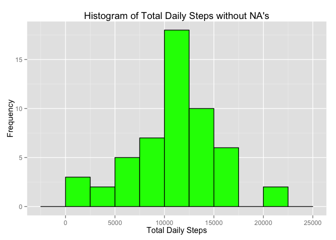

```r
ggplot(totalDailySteps, aes(x=totalSteps)) +
        geom_histogram(binwidth=2500, fill="green", colour="black") +
        ggtitle("Histogram of Total Daily Steps without NA's") +
        xlab("Total Daily Steps") + ylab("Frequency")
```

**mean and median of the total number of steps taken per day**

```r
mean(totalDailySteps$totalSteps)
```

```
## [1] 10766.19
```

```r
median(totalDailySteps$totalSteps)
```

```
## [1] 10765
```

## What is the average daily activity pattern?

**Time series plot of the 5-minute interval (x-axis) and the average number of steps taken, averaged across all days (y-axis)**

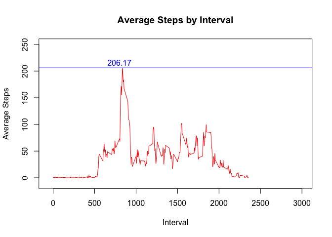

```r
stepsAvgByInterval = ddply(activity, "interval", summarize, avgSteps=mean(steps))
plot(stepsAvgByInterval$interval, stepsAvgByInterval$avgSteps, type="l", col="red", ylab="Average Steps", xlab="Interval", main="Average Steps by Interval", xlim=c(-50, 3000), ylim=c(-10, 250))
maxSteps = round(max(stepsAvgByInterval$avgSteps), digits = 2)
abline(h = maxSteps, col="blue")
text(800, maxSteps + 10, label=as.character(maxSteps), col="blue")
```

**5-minute interval, on average across all the days in the dataset, contains the maximum number of steps**

```r
stepsAvgByInterval[stepsAvgByInterval$avgSteps == max(stepsAvgByInterval$avgSteps), ]
```

```
##     interval avgSteps
## 104      835 206.1698
```

## Imputing missing values

**Total number of missing values in the dataset (i.e. the total number of rows with NAs)**

```r
nrow(activityNA)
```

```
## [1] 2304
```

**Strategy for filling in all of the missing values in the dataset, using the mean for that 5-minute interval**

*Using tidyr to spread the intervals into variables, impute the data using impute from Hmisc package and leveraging mean for each of the intervals across all days and then gather back to its original form into imputedActivity*

```r
temp = spread(origActivity, interval, steps)
names = colnames(temp)
for (name in names) {
    temp[, name] = impute(temp[, name], mean)
}

imputedActivity = gather(temp, interval, steps, -date)
imputedActivity$interval = as.numeric(as.character(imputedActivity$interval))
str(imputedActivity)
```

```
## 'data.frame':    17568 obs. of  3 variables:
##  $ date    : POSIXct, format: "2012-10-01" "2012-10-02" ...
##  $ interval: num  0 0 0 0 0 0 0 0 0 0 ...
##  $ steps   :Class 'impute'  atomic [1:17568] 1.72 0 0 47 0 ...
##   .. ..- attr(*, "imputed")= int [1:8] 1 8 32 35 40 41 45 61
```

**Total Steps by day of the imputed dataset**

```r
imputedTotalDailySteps = ddply(imputedActivity, "date", summarize, totalSteps=sum(steps))
imputedTotalDailySteps
```

```
##          date totalSteps
## 1  2012-10-01   10766.19
## 2  2012-10-02     126.00
## 3  2012-10-03   11352.00
## 4  2012-10-04   12116.00
## 5  2012-10-05   13294.00
## 6  2012-10-06   15420.00
## 7  2012-10-07   11015.00
## 8  2012-10-08   10766.19
## 9  2012-10-09   12811.00
## 10 2012-10-10    9900.00
## 11 2012-10-11   10304.00
## 12 2012-10-12   17382.00
## 13 2012-10-13   12426.00
## 14 2012-10-14   15098.00
```

[output cut: 47 more lines]

**Histogram of the total number of steps taken each day of the imputed dataset**

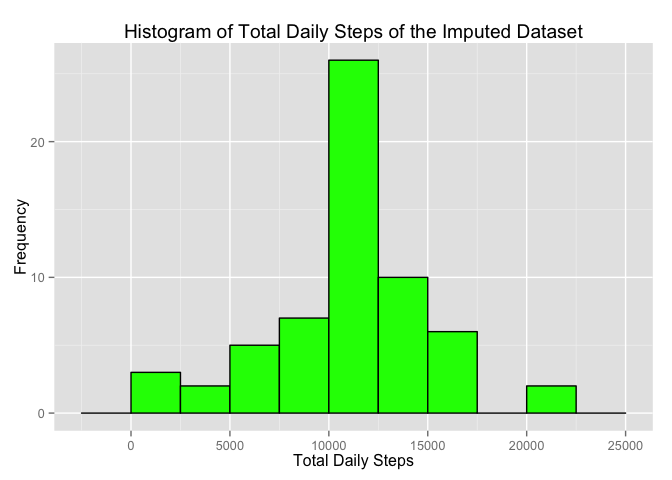

```r
ggplot(imputedTotalDailySteps, aes(x=totalSteps)) +
        geom_histogram(binwidth=2500, fill="green", colour="black") +
        ggtitle("Histogram of Total Daily Steps of the Imputed Dataset") +
        xlab("Total Daily Steps") + ylab("Frequency")
```

**Mean and Median of the total number of steps taken per day of the imputed dataset**

```r
mean(imputedTotalDailySteps$totalSteps)
```

```
## [1] 10766.19
```

```r
median(imputedTotalDailySteps$totalSteps)
```

```
## [1] 10766.19
```

**Do these values differ from the estimates from the first part of the assignment? What is the impact of imputing missing data on the estimates of the total daily number of steps?**

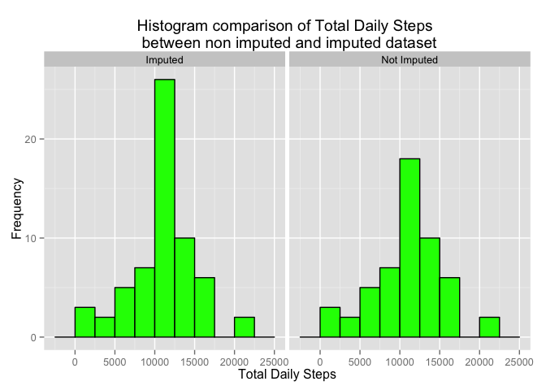

```r
totalDailySteps$imputed = "Not Imputed"
imputedTotalDailySteps$imputed="Imputed"
finalTotalDailySteps = rbind(totalDailySteps, imputedTotalDailySteps)
ggplot(finalTotalDailySteps, aes(x=totalSteps)) +
        geom_histogram(binwidth=2500, fill="green", colour="black") +
        facet_grid(. ~ imputed) +
        ggtitle("Histogram comparison of Total Daily Steps \n between non imputed and imputed dataset") +
        xlab("Total Daily Steps") + ylab("Frequency")
```

## Are there differences in activity patterns between weekdays and weekends?

**Create a new factor variable in the dataset with two levels – “weekday” and “weekend” indicating whether a given date is a weekday or weekend day**

```r
imputedActivity$day = ifelse(grepl("Saturday|Sunday", weekdays(imputedActivity$date), ignore.case = FALSE), "weekend", "weekday")
imputedActivity$day = as.factor(imputedActivity$day)
table(imputedActivity$day)
```

```
##
## weekday weekend
##   12960    4608
```

**Panel plot containing a time series plot (i.e. type = “l”) of the 5-minute interval (x-axis) and the average number of steps**

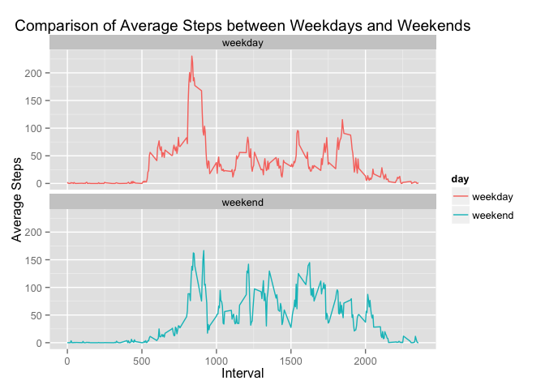

```r
stepsAvgByIntervalDay = ddply(imputedActivity, c("interval", "day"), summarize, avgSteps=mean(steps))

ggplot(stepsAvgByIntervalDay, aes(x=interval, y=avgSteps, color=day)) +
    geom_line() +
    facet_wrap(~ day, ncol=1) +
    xlab("Interval") +
    ylab("Average Steps") +
    ggtitle("Comparison of Average Steps between Weekdays and Weekends")
```